# Risk Factor Analysis

## Outcome Variable

**Outcome Variable:** stunted

## Predictor Variables

**Intervention Variable:** nrooms

**Adjustment Set:**

unadjusted

## Stratifying Variables

The analysis was stratified on these variable(s):

- agecat
- studyid
- country

## Data Summary

| agecat | studyid | country | nrooms | stunted | n_cell | n |
| --- | --- | --- | --- | --- | --- | --- |
| Birth | ki0047075b-MAL-ED | BANGLADESH | 1 | 0 | 116 | 234 |
| Birth | ki0047075b-MAL-ED | BANGLADESH | 1 | 1 | 28 | 234 |
| Birth | ki0047075b-MAL-ED | BANGLADESH | 2 | 0 | 42 | 234 |
| Birth | ki0047075b-MAL-ED | BANGLADESH | 2 | 1 | 8 | 234 |
| Birth | ki0047075b-MAL-ED | BANGLADESH | 3 | 0 | 26 | 234 |
| Birth | ki0047075b-MAL-ED | BANGLADESH | 3 | 1 | 2 | 234 |
| Birth | ki0047075b-MAL-ED | BANGLADESH | 4+ | 0 | 12 | 234 |
| Birth | ki0047075b-MAL-ED | BANGLADESH | 4+ | 1 | 0 | 234 |
| 6 months | ki0047075b-MAL-ED | BANGLADESH | 1 | 0 | 120 | 240 |
| 6 months | ki0047075b-MAL-ED | BANGLADESH | 1 | 1 | 30 | 240 |
| 6 months | ki0047075b-MAL-ED | BANGLADESH | 2 | 0 | 40 | 240 |
| 6 months | ki0047075b-MAL-ED | BANGLADESH | 2 | 1 | 10 | 240 |
| 6 months | ki0047075b-MAL-ED | BANGLADESH | 3 | 0 | 24 | 240 |
| 6 months | ki0047075b-MAL-ED | BANGLADESH | 3 | 1 | 4 | 240 |
| 6 months | ki0047075b-MAL-ED | BANGLADESH | 4+ | 0 | 11 | 240 |
| 6 months | ki0047075b-MAL-ED | BANGLADESH | 4+ | 1 | 1 | 240 |
| 24 months | ki0047075b-MAL-ED | BANGLADESH | 1 | 0 | 70 | 212 |
| 24 months | ki0047075b-MAL-ED | BANGLADESH | 1 | 1 | 64 | 212 |
| 24 months | ki0047075b-MAL-ED | BANGLADESH | 2 | 0 | 21 | 212 |
| 24 months | ki0047075b-MAL-ED | BANGLADESH | 2 | 1 | 19 | 212 |
| 24 months | ki0047075b-MAL-ED | BANGLADESH | 3 | 0 | 16 | 212 |
| 24 months | ki0047075b-MAL-ED | BANGLADESH | 3 | 1 | 11 | 212 |
| 24 months | ki0047075b-MAL-ED | BANGLADESH | 4+ | 0 | 7 | 212 |
| 24 months | ki0047075b-MAL-ED | BANGLADESH | 4+ | 1 | 4 | 212 |
| Birth | ki0047075b-MAL-ED | BRAZIL | 1 | 0 | 3 | 174 |
| Birth | ki0047075b-MAL-ED | BRAZIL | 1 | 1 | 0 | 174 |
| Birth | ki0047075b-MAL-ED | BRAZIL | 2 | 0 | 18 | 174 |
| Birth | ki0047075b-MAL-ED | BRAZIL | 2 | 1 | 1 | 174 |
| Birth | ki0047075b-MAL-ED | BRAZIL | 3 | 0 | 43 | 174 |
| Birth | ki0047075b-MAL-ED | BRAZIL | 3 | 1 | 7 | 174 |

[output cut: 328 more lines]

The following strata were considered:

- agecat: 24 months, studyid: ki0047075b-MAL-ED, country: BANGLADESH
- agecat: 24 months, studyid: ki0047075b-MAL-ED, country: BRAZIL
- agecat: 24 months, studyid: ki0047075b-MAL-ED, country: INDIA
- agecat: 24 months, studyid: ki0047075b-MAL-ED, country: NEPAL
- agecat: 24 months, studyid: ki0047075b-MAL-ED, country: PERU
- agecat: 24 months, studyid: ki0047075b-MAL-ED, country: SOUTH AFRICA
- agecat: 24 months, studyid: ki0047075b-MAL-ED, country: TANZANIA, UNITED REPUBLIC OF
- agecat: 24 months, studyid: ki1000108-CMC-V-BCS-2002, country: INDIA
- agecat: 24 months, studyid: ki1000108-IRC, country: INDIA
- agecat: 24 months, studyid: ki1017093b-PROVIDE, country: BANGLADESH
- agecat: 24 months, studyid: ki1017093c-NIH-Crypto, country: BANGLADESH
- agecat: 24 months, studyid: ki1113344-GMS-Nepal, country: NEPAL
- agecat: 24 months, studyid: ki1114097-CONTENT, country: PERU
- agecat: 24 months, studyid: ki1135781-COHORTS, country: INDIA
- agecat: 24 months, studyid: kiGH5241-JiVitA-3, country: BANGLADESH
- agecat: 24 months, studyid: kiGH5241-JiVitA-4, country: BANGLADESH
- agecat: 6 months, studyid: ki0047075b-MAL-ED, country: BANGLADESH
- agecat: 6 months, studyid: ki0047075b-MAL-ED, country: BRAZIL
- agecat: 6 months, studyid: ki0047075b-MAL-ED, country: INDIA
- agecat: 6 months, studyid: ki0047075b-MAL-ED, country: NEPAL
- agecat: 6 months, studyid: ki0047075b-MAL-ED, country: PERU
- agecat: 6 months, studyid: ki0047075b-MAL-ED, country: SOUTH AFRICA
- agecat: 6 months, studyid: ki0047075b-MAL-ED, country: TANZANIA, UNITED REPUBLIC OF
- agecat: 6 months, studyid: ki1000108-CMC-V-BCS-2002, country: INDIA
- agecat: 6 months, studyid: ki1000108-IRC, country: INDIA
- agecat: 6 months, studyid: ki1017093b-PROVIDE, country: BANGLADESH
- agecat: 6 months, studyid: ki1017093c-NIH-Crypto, country: BANGLADESH
- agecat: 6 months, studyid: ki1113344-GMS-Nepal, country: NEPAL
- agecat: 6 months, studyid: ki1114097-CONTENT, country: PERU
- agecat: 6 months, studyid: ki1135781-COHORTS, country: INDIA
- agecat: 6 months, studyid: kiGH5241-JiVitA-3, country: BANGLADESH
- agecat: 6 months, studyid: kiGH5241-JiVitA-4, country: BANGLADESH
- agecat: Birth, studyid: ki0047075b-MAL-ED, country: BANGLADESH
- agecat: Birth, studyid: ki0047075b-MAL-ED, country: BRAZIL
- agecat: Birth, studyid: ki0047075b-MAL-ED, country: INDIA
- agecat: Birth, studyid: ki0047075b-MAL-ED, country: NEPAL
- agecat: Birth, studyid: ki0047075b-MAL-ED, country: PERU
- agecat: Birth, studyid: ki0047075b-MAL-ED, country: SOUTH AFRICA
- agecat: Birth, studyid: ki0047075b-MAL-ED, country: TANZANIA, UNITED REPUBLIC OF
- agecat: Birth, studyid: ki1000108-CMC-V-BCS-2002, country: INDIA
- agecat: Birth, studyid: ki1000108-IRC, country: INDIA
- agecat: Birth, studyid: ki1017093c-NIH-Crypto, country: BANGLADESH
- agecat: Birth, studyid: ki1114097-CONTENT, country: PERU
- agecat: Birth, studyid: ki1135781-COHORTS, country: INDIA
- agecat: Birth, studyid: kiGH5241-JiVitA-3, country: BANGLADESH
- agecat: Birth, studyid: kiGH5241-JiVitA-4, country: BANGLADESH

### Dropped Strata

Some strata were dropped due to rare outcomes:

- agecat: Birth, studyid: ki0047075b-MAL-ED, country: BANGLADESH
- agecat: 6 months, studyid: ki0047075b-MAL-ED, country: BANGLADESH
- agecat: 24 months, studyid: ki0047075b-MAL-ED, country: BANGLADESH
- agecat: Birth, studyid: ki0047075b-MAL-ED, country: BRAZIL
- agecat: 6 months, studyid: ki0047075b-MAL-ED, country: BRAZIL
- agecat: 24 months, studyid: ki0047075b-MAL-ED, country: BRAZIL
- agecat: Birth, studyid: ki0047075b-MAL-ED, country: INDIA
- agecat: 6 months, studyid: ki0047075b-MAL-ED, country: INDIA
- agecat: 6 months, studyid: ki0047075b-MAL-ED, country: NEPAL
- agecat: Birth, studyid: ki0047075b-MAL-ED, country: NEPAL
- agecat: Birth, studyid: ki0047075b-MAL-ED, country: PERU
- agecat: Birth, studyid: ki0047075b-MAL-ED, country: SOUTH AFRICA
- agecat: 6 months, studyid: ki0047075b-MAL-ED, country: SOUTH AFRICA
- agecat: Birth, studyid: ki0047075b-MAL-ED, country: TANZANIA, UNITED REPUBLIC OF
- agecat: 6 months, studyid: ki0047075b-MAL-ED, country: TANZANIA, UNITED REPUBLIC OF
- agecat: 24 months, studyid: ki0047075b-MAL-ED, country: TANZANIA, UNITED REPUBLIC OF
- agecat: 6 months, studyid: ki1000108-CMC-V-BCS-2002, country: INDIA
- agecat: Birth, studyid: ki1000108-CMC-V-BCS-2002, country: INDIA
- agecat: 6 months, studyid: ki1000108-IRC, country: INDIA
- agecat: Birth, studyid: ki1000108-IRC, country: INDIA
- agecat: 6 months, studyid: ki1017093b-PROVIDE, country: BANGLADESH
- agecat: Birth, studyid: ki1017093c-NIH-Crypto, country: BANGLADESH
- agecat: 6 months, studyid: ki1114097-CONTENT, country: PERU
- agecat: 24 months, studyid: ki1114097-CONTENT, country: PERU
- agecat: Birth, studyid: ki1114097-CONTENT, country: PERU

## Methods Detail

We’re interested in the causal parameters $E[Y_a]$ for all values of $a \in \mathcal{A}$. These parameters represent the mean outcome if, possibly contrary to fact, we intervened to set all units to have $A=a$. Under the randomization and positivity assumptions, these are identified by the statistical parameters $\psi_a=E_W[E_{Y|A,W}(Y|A=a,W)]$. In addition, we’re interested in the mean of $Y$, $E[Y]$ under no intervention (the observed mean). We will estimate these parameters by using SuperLearner to fit the relevant likelihood factors – $E_{Y|A,W}(Y|A=a,W)$ and $p(A=a|W)$, and then updating our likelihood fit using a joint TMLE.

For unadjusted analyses ($W=\{\}$), initial likelihoods were estimated using Lrnr_glm to estimate the simple $E(Y|A)$ and Lrnr_mean to estimate $p(A)$. For adjusted analyses, a small library containing Lrnr_glmnet, Lrnr_xgboost, and Lrnr_mean was used.

Having estimated these parameters, we will then use the delta method to estimate relative risks and attributable risks relative to a prespecified baseline level of $A$.

# Results Detail

## Results Plots

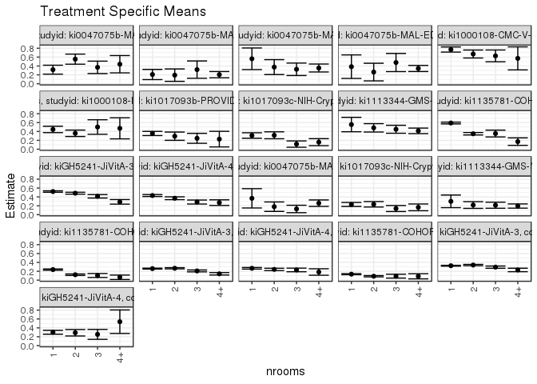

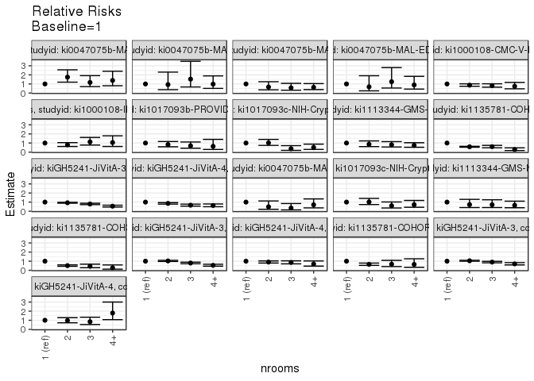

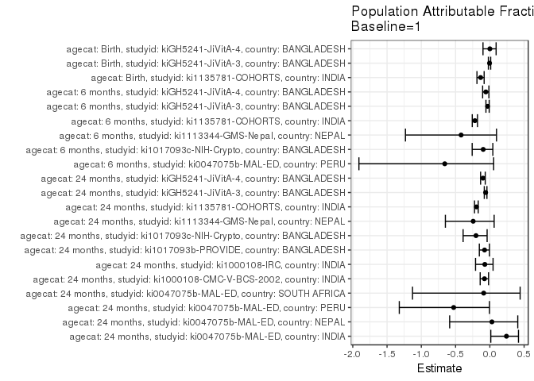

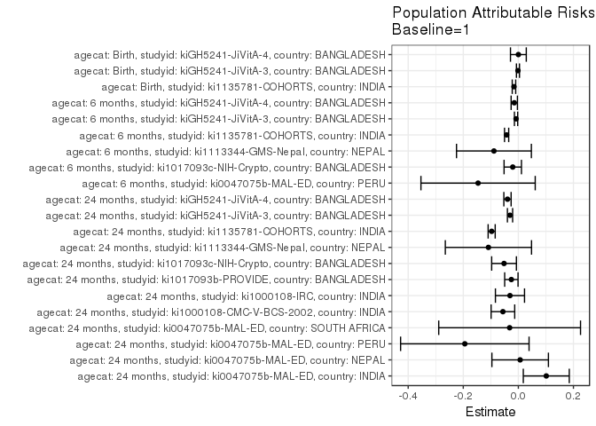

## Results Table

### Parameter: TSM

| agecat | studyid | country | intervention_level | baseline_level | estimate | ci_lower | ci_upper |
| --- | --- | --- | --- | --- | --- | --- | --- |
| Birth | ki1135781-COHORTS | INDIA | 1 | NA | 0.1344000 | 0.1224401 | 0.1463599 |
| Birth | ki1135781-COHORTS | INDIA | 2 | NA | 0.0880866 | 0.0731587 | 0.1030146 |
| Birth | ki1135781-COHORTS | INDIA | 3 | NA | 0.0898204 | 0.0464507 | 0.1331901 |
| Birth | ki1135781-COHORTS | INDIA | 4+ | NA | 0.0869565 | 0.0293732 | 0.1445398 |
| Birth | kiGH5241-JiVitA-3 | BANGLADESH | 1 | NA | 0.3248154 | 0.3153610 | 0.3342699 |
| Birth | kiGH5241-JiVitA-3 | BANGLADESH | 2 | NA | 0.3400430 | 0.3256895 | 0.3543965 |
| Birth | kiGH5241-JiVitA-3 | BANGLADESH | 3 | NA | 0.2927611 | 0.2676177 | 0.3179044 |
| Birth | kiGH5241-JiVitA-3 | BANGLADESH | 4+ | NA | 0.2294521 | 0.1902132 | 0.2686909 |
| Birth | kiGH5241-JiVitA-4 | BANGLADESH | 1 | NA | 0.3003953 | 0.2572078 | 0.3435827 |
| Birth | kiGH5241-JiVitA-4 | BANGLADESH | 2 | NA | 0.2898551 | 0.2171612 | 0.3625490 |
| Birth | kiGH5241-JiVitA-4 | BANGLADESH | 3 | NA | 0.2530120 | 0.1415517 | 0.3644724 |
| Birth | kiGH5241-JiVitA-4 | BANGLADESH | 4+ | NA | 0.5384615 | 0.2737918 | 0.8031312 |
| 6 months | ki0047075b-MAL-ED | PERU | 1 | NA | 0.3684211 | 0.1511194 | 0.5857227 |
| 6 months | ki0047075b-MAL-ED | PERU | 2 | NA | 0.1800000 | 0.0733129 | 0.2866871 |
| 6 months | ki0047075b-MAL-ED | PERU | 3 | NA | 0.1290323 | 0.0454319 | 0.2126326 |
| 6 months | ki0047075b-MAL-ED | PERU | 4+ | NA | 0.2589928 | 0.1860300 | 0.3319556 |
| 6 months | ki1017093c-NIH-Crypto | BANGLADESH | 1 | NA | 0.2300885 | 0.1852532 | 0.2749238 |
| 6 months | ki1017093c-NIH-Crypto | BANGLADESH | 2 | NA | 0.2336957 | 0.1725073 | 0.2948840 |
| 6 months | ki1017093c-NIH-Crypto | BANGLADESH | 3 | NA | 0.1386139 | 0.0711776 | 0.2060501 |
| 6 months | ki1017093c-NIH-Crypto | BANGLADESH | 4+ | NA | 0.1648352 | 0.0885496 | 0.2411207 |
| 6 months | ki1113344-GMS-Nepal | NEPAL | 1 | NA | 0.3000000 | 0.1578608 | 0.4421392 |
| 6 months | ki1113344-GMS-Nepal | NEPAL | 2 | NA | 0.2173913 | 0.1419379 | 0.2928447 |
| 6 months | ki1113344-GMS-Nepal | NEPAL | 3 | NA | 0.2127660 | 0.1451534 | 0.2803785 |
| 6 months | ki1113344-GMS-Nepal | NEPAL | 4+ | NA | 0.1947566 | 0.1472134 | 0.2422997 |
| 6 months | ki1135781-COHORTS | INDIA | 1 | NA | 0.2380952 | 0.2233666 | 0.2528239 |
| 6 months | ki1135781-COHORTS | INDIA | 2 | NA | 0.1221167 | 0.1054000 | 0.1388333 |
| 6 months | ki1135781-COHORTS | INDIA | 3 | NA | 0.1043956 | 0.0599677 | 0.1488235 |
| 6 months | ki1135781-COHORTS | INDIA | 4+ | NA | 0.0645161 | 0.0145814 | 0.1144509 |
| 6 months | kiGH5241-JiVitA-3 | BANGLADESH | 1 | NA | 0.2597403 | 0.2495310 | 0.2699495 |
| 6 months | kiGH5241-JiVitA-3 | BANGLADESH | 2 | NA | 0.2672996 | 0.2537128 | 0.2808863 |

[output cut: 54 more lines]

### Parameter: E(Y)

| agecat | studyid | country | intervention_level | baseline_level | estimate | ci_lower | ci_upper |
| --- | --- | --- | --- | --- | --- | --- | --- |
| Birth | ki1135781-COHORTS | INDIA | NA | NA | 0.1184735 | 0.1093005 | 0.1276464 |
| Birth | kiGH5241-JiVitA-3 | BANGLADESH | NA | NA | 0.3233958 | 0.3157274 | 0.3310641 |
| Birth | kiGH5241-JiVitA-4 | BANGLADESH | NA | NA | 0.3004866 | 0.2649179 | 0.3360553 |
| 6 months | ki0047075b-MAL-ED | PERU | NA | NA | 0.2222222 | 0.1725409 | 0.2719036 |
| 6 months | ki1017093c-NIH-Crypto | BANGLADESH | NA | NA | 0.2097902 | 0.1799252 | 0.2396552 |
| 6 months | ki1113344-GMS-Nepal | NEPAL | NA | NA | 0.2113677 | 0.1776128 | 0.2451225 |
| 6 months | ki1135781-COHORTS | INDIA | NA | NA | 0.1954857 | 0.1844503 | 0.2065211 |
| 6 months | kiGH5241-JiVitA-3 | BANGLADESH | NA | NA | 0.2514286 | 0.2432985 | 0.2595587 |
| 6 months | kiGH5241-JiVitA-4 | BANGLADESH | NA | NA | 0.2522280 | 0.2381653 | 0.2662906 |
| 24 months | ki0047075b-MAL-ED | INDIA | NA | NA | 0.4185022 | 0.3541865 | 0.4828179 |
| 24 months | ki0047075b-MAL-ED | NEPAL | NA | NA | 0.2149123 | 0.1614774 | 0.2683472 |
| 24 months | ki0047075b-MAL-ED | PERU | NA | NA | 0.3681592 | 0.3013164 | 0.4350020 |
| 24 months | ki0047075b-MAL-ED | SOUTH AFRICA | NA | NA | 0.3529412 | 0.2921001 | 0.4137823 |
| 24 months | ki1000108-CMC-V-BCS-2002 | INDIA | NA | NA | 0.7150538 | 0.6691221 | 0.7609854 |
| 24 months | ki1000108-IRC | INDIA | NA | NA | 0.4152334 | 0.3673018 | 0.4631651 |
| 24 months | ki1017093b-PROVIDE | BANGLADESH | NA | NA | 0.3292894 | 0.2909105 | 0.3676684 |
| 24 months | ki1017093c-NIH-Crypto | BANGLADESH | NA | NA | 0.2568093 | 0.2190047 | 0.2946140 |
| 24 months | ki1113344-GMS-Nepal | NEPAL | NA | NA | 0.4468938 | 0.4032281 | 0.4905594 |
| 24 months | ki1135781-COHORTS | INDIA | NA | NA | 0.4934649 | 0.4774590 | 0.5094709 |
| 24 months | kiGH5241-JiVitA-3 | BANGLADESH | NA | NA | 0.4908353 | 0.4776984 | 0.5039721 |
| 24 months | kiGH5241-JiVitA-4 | BANGLADESH | NA | NA | 0.3922477 | 0.3752571 | 0.4092384 |

### Parameter: RR

| agecat | studyid | country | intervention_level | baseline_level | estimate | ci_lower | ci_upper |
| --- | --- | --- | --- | --- | --- | --- | --- |
| Birth | ki1135781-COHORTS | INDIA | 1 | 1 | 1.0000000 | 1.0000000 | 1.0000000 |
| Birth | ki1135781-COHORTS | INDIA | 2 | 1 | 0.6554066 | 0.5412298 | 0.7936699 |
| Birth | ki1135781-COHORTS | INDIA | 3 | 1 | 0.6683062 | 0.4090207 | 1.0919576 |
| Birth | ki1135781-COHORTS | INDIA | 4+ | 1 | 0.6469979 | 0.3316841 | 1.2620634 |
| Birth | kiGH5241-JiVitA-3 | BANGLADESH | 1 | 1 | 1.0000000 | 1.0000000 | 1.0000000 |
| Birth | kiGH5241-JiVitA-3 | BANGLADESH | 2 | 1 | 1.0468806 | 0.9963059 | 1.1000226 |
| Birth | kiGH5241-JiVitA-3 | BANGLADESH | 3 | 1 | 0.9013151 | 0.8235129 | 0.9864676 |
| Birth | kiGH5241-JiVitA-3 | BANGLADESH | 4+ | 1 | 0.7064075 | 0.5930771 | 0.8413939 |
| Birth | kiGH5241-JiVitA-4 | BANGLADESH | 1 | 1 | 1.0000000 | 1.0000000 | 1.0000000 |
| Birth | kiGH5241-JiVitA-4 | BANGLADESH | 2 | 1 | 0.9649123 | 0.7231208 | 1.2875522 |
| Birth | kiGH5241-JiVitA-4 | BANGLADESH | 3 | 1 | 0.8422638 | 0.5308383 | 1.3363925 |
| Birth | kiGH5241-JiVitA-4 | BANGLADESH | 4+ | 1 | 1.7925101 | 1.0707991 | 3.0006493 |
| 6 months | ki0047075b-MAL-ED | PERU | 1 | 1 | 1.0000000 | 1.0000000 | 1.0000000 |
| 6 months | ki0047075b-MAL-ED | PERU | 2 | 1 | 0.4885714 | 0.2117300 | 1.1273891 |
| 6 months | ki0047075b-MAL-ED | PERU | 3 | 1 | 0.3502304 | 0.1458278 | 0.8411381 |
| 6 months | ki0047075b-MAL-ED | PERU | 4+ | 1 | 0.7029805 | 0.3656530 | 1.3515042 |
| 6 months | ki1017093c-NIH-Crypto | BANGLADESH | 1 | 1 | 1.0000000 | 1.0000000 | 1.0000000 |
| 6 months | ki1017093c-NIH-Crypto | BANGLADESH | 2 | 1 | 1.0156773 | 0.7328408 | 1.4076731 |
| 6 months | ki1017093c-NIH-Crypto | BANGLADESH | 3 | 1 | 0.6024372 | 0.3567037 | 1.0174565 |
| 6 months | ki1017093c-NIH-Crypto | BANGLADESH | 4+ | 1 | 0.7163990 | 0.4335851 | 1.1836835 |
| 6 months | ki1113344-GMS-Nepal | NEPAL | 1 | 1 | 1.0000000 | 1.0000000 | 1.0000000 |
| 6 months | ki1113344-GMS-Nepal | NEPAL | 2 | 1 | 0.7246377 | 0.4027619 | 1.3037475 |
| 6 months | ki1113344-GMS-Nepal | NEPAL | 3 | 1 | 0.7092199 | 0.4008824 | 1.2547142 |
| 6 months | ki1113344-GMS-Nepal | NEPAL | 4+ | 1 | 0.6491885 | 0.3809755 | 1.1062280 |
| 6 months | ki1135781-COHORTS | INDIA | 1 | 1 | 1.0000000 | 1.0000000 | 1.0000000 |
| 6 months | ki1135781-COHORTS | INDIA | 2 | 1 | 0.5128901 | 0.4413519 | 0.5960238 |
| 6 months | ki1135781-COHORTS | INDIA | 3 | 1 | 0.4384615 | 0.2852105 | 0.6740583 |
| 6 months | ki1135781-COHORTS | INDIA | 4+ | 1 | 0.2709677 | 0.1246542 | 0.5890177 |
| 6 months | kiGH5241-JiVitA-3 | BANGLADESH | 1 | 1 | 1.0000000 | 1.0000000 | 1.0000000 |
| 6 months | kiGH5241-JiVitA-3 | BANGLADESH | 2 | 1 | 1.0291034 | 0.9690625 | 1.0928642 |

[output cut: 54 more lines]

### Parameter: PAR

| agecat | studyid | country | intervention_level | baseline_level | estimate | ci_lower | ci_upper |
| --- | --- | --- | --- | --- | --- | --- | --- |
| Birth | ki1135781-COHORTS | INDIA | 1 | NA | -0.0159265 | -0.0222291 | -0.0096240 |
| Birth | kiGH5241-JiVitA-3 | BANGLADESH | 1 | NA | -0.0014197 | -0.0069429 | 0.0041036 |
| Birth | kiGH5241-JiVitA-4 | BANGLADESH | 1 | NA | 0.0000914 | -0.0286091 | 0.0287918 |
| 6 months | ki0047075b-MAL-ED | PERU | 1 | NA | -0.1461988 | -0.3536656 | 0.0612680 |
| 6 months | ki1017093c-NIH-Crypto | BANGLADESH | 1 | NA | -0.0202983 | -0.0518569 | 0.0112603 |
| 6 months | ki1113344-GMS-Nepal | NEPAL | 1 | NA | -0.0886323 | -0.2245444 | 0.0472798 |
| 6 months | ki1135781-COHORTS | INDIA | 1 | NA | -0.0426095 | -0.0502106 | -0.0350085 |
| 6 months | kiGH5241-JiVitA-3 | BANGLADESH | 1 | NA | -0.0083117 | -0.0142558 | -0.0023676 |
| 6 months | kiGH5241-JiVitA-4 | BANGLADESH | 1 | NA | -0.0147896 | -0.0262204 | -0.0033587 |
| 24 months | ki0047075b-MAL-ED | INDIA | 1 | NA | 0.1014290 | 0.0179766 | 0.1848814 |
| 24 months | ki0047075b-MAL-ED | NEPAL | 1 | NA | 0.0065789 | -0.0960405 | 0.1091984 |
| 24 months | ki0047075b-MAL-ED | PERU | 1 | NA | -0.1943408 | -0.4275676 | 0.0388860 |
| 24 months | ki0047075b-MAL-ED | SOUTH AFRICA | 1 | NA | -0.0316742 | -0.2890923 | 0.2257439 |
| 24 months | ki1000108-CMC-V-BCS-2002 | INDIA | 1 | NA | -0.0560905 | -0.0989505 | -0.0132305 |
| 24 months | ki1000108-IRC | INDIA | 1 | NA | -0.0304188 | -0.0832666 | 0.0224290 |
| 24 months | ki1017093b-PROVIDE | BANGLADESH | 1 | NA | -0.0253904 | -0.0496680 | -0.0011127 |
| 24 months | ki1017093c-NIH-Crypto | BANGLADESH | 1 | NA | -0.0519464 | -0.0968728 | -0.0070200 |
| 24 months | ki1113344-GMS-Nepal | NEPAL | 1 | NA | -0.1086618 | -0.2651794 | 0.0478559 |
| 24 months | ki1135781-COHORTS | INDIA | 1 | NA | -0.0968913 | -0.1097026 | -0.0840800 |
| 24 months | kiGH5241-JiVitA-3 | BANGLADESH | 1 | NA | -0.0302497 | -0.0397133 | -0.0207861 |
| 24 months | kiGH5241-JiVitA-4 | BANGLADESH | 1 | NA | -0.0394482 | -0.0526577 | -0.0262387 |

### Parameter: PAF

| agecat | studyid | country | intervention_level | baseline_level | estimate | ci_lower | ci_upper |
| --- | --- | --- | --- | --- | --- | --- | --- |
| Birth | ki1135781-COHORTS | INDIA | 1 | NA | -0.1344312 | -0.1881499 | -0.0831412 |
| Birth | kiGH5241-JiVitA-3 | BANGLADESH | 1 | NA | -0.0043899 | -0.0216149 | 0.0125448 |
| Birth | kiGH5241-JiVitA-4 | BANGLADESH | 1 | NA | 0.0003040 | -0.0999165 | 0.0913929 |
| 6 months | ki0047075b-MAL-ED | PERU | 1 | NA | -0.6578947 | -1.9104416 | 0.0556021 |
| 6 months | ki1017093c-NIH-Crypto | BANGLADESH | 1 | NA | -0.0967552 | -0.2576867 | 0.0435838 |
| 6 months | ki1113344-GMS-Nepal | NEPAL | 1 | NA | -0.4193277 | -1.2314143 | 0.0972133 |
| 6 months | ki1135781-COHORTS | INDIA | 1 | NA | -0.2179676 | -0.2566491 | -0.1804767 |
| 6 months | kiGH5241-JiVitA-3 | BANGLADESH | 1 | NA | -0.0330579 | -0.0569650 | -0.0096915 |
| 6 months | kiGH5241-JiVitA-4 | BANGLADESH | 1 | NA | -0.0586357 | -0.1050488 | -0.0141720 |
| 24 months | ki0047075b-MAL-ED | INDIA | 1 | NA | 0.2423620 | 0.0138415 | 0.4179279 |
| 24 months | ki0047075b-MAL-ED | NEPAL | 1 | NA | 0.0306122 | -0.5863776 | 0.4076362 |
| 24 months | ki0047075b-MAL-ED | PERU | 1 | NA | -0.5278716 | -1.3214412 | -0.0055786 |
| 24 months | ki0047075b-MAL-ED | SOUTH AFRICA | 1 | NA | -0.0897436 | -1.1281603 | 0.4419870 |
| 24 months | ki1000108-CMC-V-BCS-2002 | INDIA | 1 | NA | -0.0784424 | -0.1410597 | -0.0192613 |
| 24 months | ki1000108-IRC | INDIA | 1 | NA | -0.0732570 | -0.2085489 | 0.0468895 |
| 24 months | ki1017093b-PROVIDE | BANGLADESH | 1 | NA | -0.0771066 | -0.1534495 | -0.0058165 |
| 24 months | ki1017093c-NIH-Crypto | BANGLADESH | 1 | NA | -0.2022762 | -0.3900887 | -0.0398387 |
| 24 months | ki1113344-GMS-Nepal | NEPAL | 1 | NA | -0.2431490 | -0.6487751 | 0.0626863 |
| 24 months | ki1135781-COHORTS | INDIA | 1 | NA | -0.1963489 | -0.2236370 | -0.1696693 |
| 24 months | kiGH5241-JiVitA-3 | BANGLADESH | 1 | NA | -0.0616290 | -0.0811507 | -0.0424597 |
| 24 months | kiGH5241-JiVitA-4 | BANGLADESH | 1 | NA | -0.1005696 | -0.1349983 | -0.0671853 |